# [Stories from the Archives](https://blogs.archives.qld.gov.au/)

## Queensland State Archives

# Escape from St Helena Island

[21 April, 2021](https://blogs.archives.qld.gov.au/2021/04/21/escape-from-st-helena-island/) By [Queensland State Archives](https://blogs.archives.qld.gov.au/author/qsarchives/)

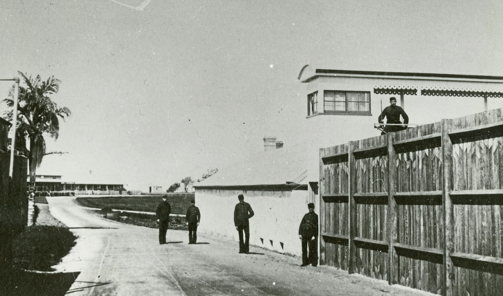

Sitting isolated, surrounded by the dangers of Moreton Bay, St Helena Island Penal Establishment was a fortified prison. Despite this, numerous prisoners still attempted to escape.

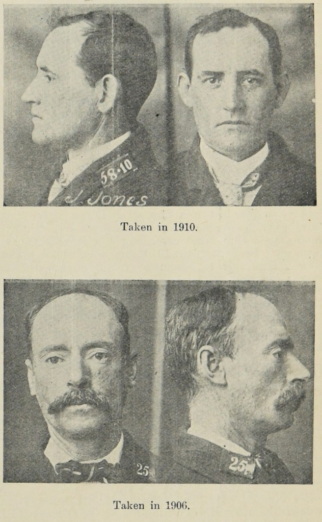

<sub>[ITM519924 David McIntyre (top) and](https://www.archivessearch.qld.gov.au/items/ITM519924) [Henry Craig (bottom)](https://www.archivessearch.qld.gov.au/items/ITM519924)</sub>

One of the greatest escape attempts lasted 11 days and was carried out by two prisoners: Henry Craig and David McIntyre. The response to their escape was unprecedented, with police forces across Australia placed on high alert.

In November 1911, Craig and McIntyre planned their escape. Coordinating to be in the hospital on the same night, McIntyre had secured the tools required for the escape from the tailor shop. Craig had been gifted three-quarters of a cup (six ounces) of whisky from Warder Rawlinson. On the night of 5 November, the escape began with the whisky being distributed to other inmates in the hospital.

Using the tools from the tailor shop, Craig and McIntyre chiselled out the door jamb during the night. They started their escape at 4am. By leaving the door intact, the alarm was not raised until 5.25am.

On the first day of their escape, Craig and McIntyre moved from the hospital through the lumberyard, before hiding in the tinsmith’s workshop roof. From 6 to 15 November, Craig and McIntyre remained hidden in the cavity. Food was secretly delivered by a fellow inmate.

After nightfall on 16 November, Craig and McIntyre left the roof and acquired tools from the workshops to scale one of the prison gates. Once out, they made their way to the boathouse where they attempted to move two boats. They were unsuccessful. After failing to coerce a horse into dragging the smaller boat to shore, they gave up.

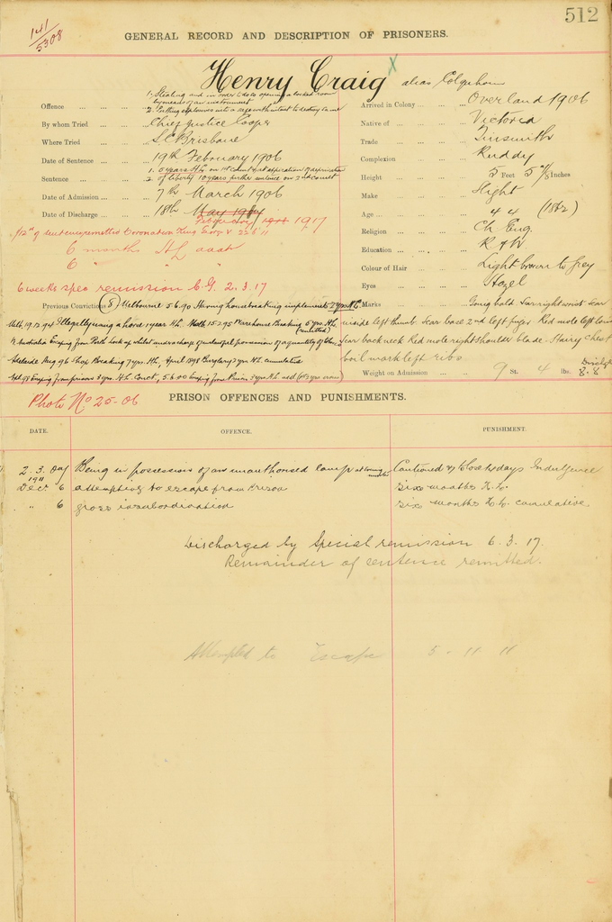

- ITM271423 General record and description of male prisoners p.512

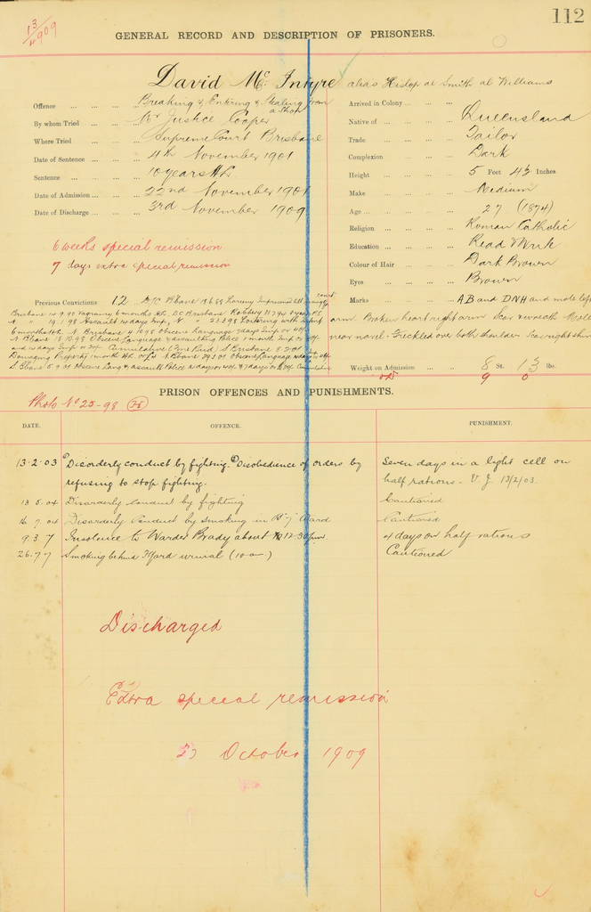

- ITM271423 General record and description of male prisoners p.112

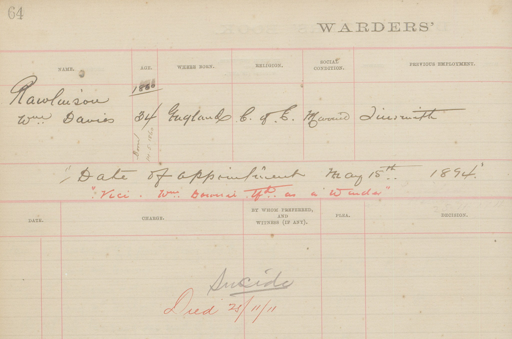

<sup>ITM271614 Warders Defaulters 1882-1931</sup>

## Building a gaol for Brisbane

By the 1860s, conditions at Brisbane Gaol on the mainland were deteriorating due to overcrowding. In 1867, prisoners stationed on the hulk *Proserpine* were building the St Helena Stockade which was to be Brisbane’s new gaol. Originally meant as a quarantine station, it was isolated from the mainland; the island itself was used for farming, its rich, volcanic soil ideal for growing maize, potatoes and other vegetables. The prisoners were made to learn trades, supporting the island with numerous exports such as bricks, clothes, rope, boots and sugar. At the time, St Helena was considered a model high-security prison.

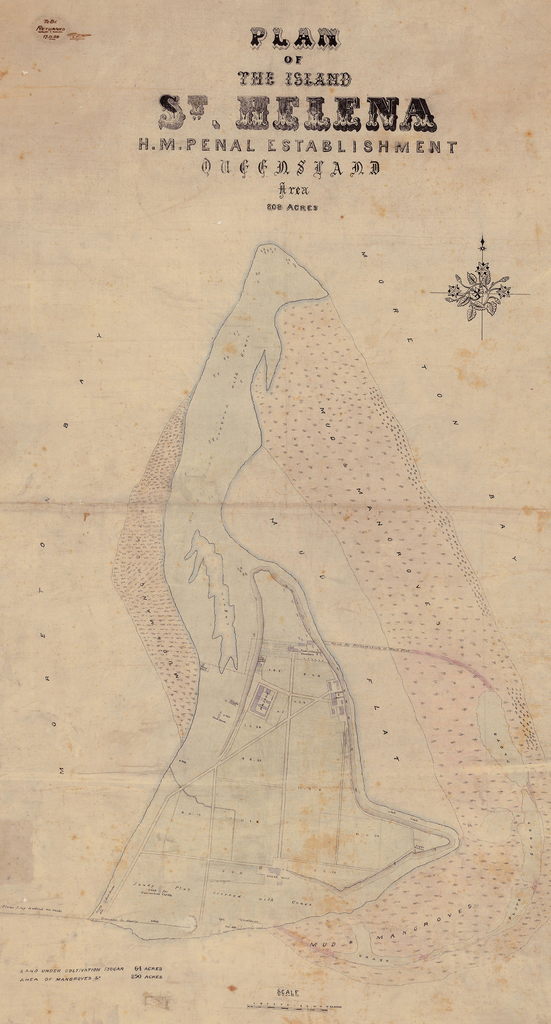

<sub>ITM328241 **Plan of St Helena Island and the key prison buildings, c.1884**</sub>

See more buildings, plans and photographs from St Helena Island in [our album here](https://www.flickr.com/search/?user_id=60455048%40N02&view_all=1&text=St%20Helena).

### About Queensland State Archives

For more information about Queensland State Archives visit www.archives.qld.gov.au.

## Subscribe to QSA

The text of our blog posts is available under a [Creative Commons Attribution 3.0 Australia (CC BY 3.0) licence](https://creativecommons.org/licenses/by/3.0/au/).